← Back to R & Statistics

# Simple Linear Regression

```r
# Load your libraries
library(car)
library(tidyverse)
library(pander)
library(ggplot2)
library(DT)

# Load your data after saving a csv file in your Data folder.
# You can use either
#   someName <- read.csv("../Data/YourDataFileName.csv", header=TRUE)
# or
#   library(readr)
#   someName <- read_csv("../Data/YourDataFileName.csv")

netflix <- read_csv("../../Data/NetflixEngagementDataset.csv")

# Don't forget to run "Session -> Set Working Directory -> To Source file location"
```

### Data

#### Dataset for our Analyse

```r
datatable(netflix |>select(`Daily Watch Time (Hours)`, `Monthly Income ($)`))
```

|  | Daily Watch Time (Hours) | Monthly Income ($) |
| --- | --- | --- |
| 1 | 4.32 | 3307 |
| 2 | 4.45 | 7333 |
| 3 | 4.81 | 7527 |
| 4 | 2.67 | 9934 |
| 5 | 4.2 | 6242 |
| 6 | 2.99 | 5897 |
| 7 | 2.8 | 2231 |
| 8 | 5.51 | 2173 |
| 9 | 2.2 | 4742 |
| 10 | 3.05 | 7278 |

[output cut: 3490 more lines]

*My goal is to explore how daily watch time is influenced by monthly income.*

**Question: does monthly income impact the daily watch time of individuals?**

#### Full Dataset

```r
datatable(netflix)
```

|  | Customer ID | Subscription Length (Months) | Customer Satisfaction Score (1-10) | Daily Watch Time (Hours) | Engagement Rate (1-10) | Device Used Most Often | Genre Preference | Region | Payment History (On-Time/Delayed) | Subscription Plan | Churn Status (Yes/No) | Support Queries Logged | Age | Monthly Income ($) | Promotional Offers Used | Number of Profiles Created |
| --- | --- | --- | --- | --- | --- | --- | --- | --- | --- | --- | --- | --- | --- | --- | --- | --- |
| 1 | 1 | 50 | 10 | 4.32 | 8 | Mobile | Romance | Oceania | On-Time | Premium | No | 9 | 26 | 3307 | Yes | 2 |
| 2 | 2 | 40 | 5 | 4.45 | 3 | Smart TV | Comedy | Asia | On-Time | Premium | No | 6 | 27 | 7333 | Yes | 2 |
| 3 | 3 | 17 | 8 | 4.81 | 8 | Laptop | Sci-fi | South America | On-Time | Basic | No | 0 | 55 | 7527 | Yes | 3 |
| 4 | 4 | 59 | 10 | 2.67 | 10 | Mobile | Action | Africa | On-Time | Basic | No | 1 | 29 | 9934 | Yes | 3 |
| 5 | 5 | 5 | 7 | 4.2 | 9 | Smart TV | Sci-fi | North America | On-Time | Standard | No | 7 | 45 | 6242 | Yes | 3 |
| 6 | 6 | 1 | 7 | 2.99 | 8 | Laptop | Romance | Africa | On-Time | Basic | No | 0 | 54 | 5897 | No | 3 |
| 7 | 7 | 19 | 9 | 2.8 | 8 | Laptop | Sci-fi | South America | Delayed | Standard | Yes | 1 | 23 | 2231 | No | 3 |
| 8 | 8 | 59 | 8 | 5.51 | 9 | Laptop | Drama | Africa | On-Time | Basic | No | 9 | 57 | 2173 | Yes | 3 |
| 9 | 9 | 37 | 4 | 2.2 | 5 | Mobile | Drama | Asia | On-Time | Standard | No | 5 | 51 | 4742 | No | 4 |
| 10 | 10 | 53 | 8 | 3.05 | 9 | Tablet | Romance | North America | On-Time | Basic | No | 2 | 67 | 7278 | No | 5 |

[output cut: 3490 more lines]

### Objective

As mentioned earlier, we aim to understand the average watch time based on monthly income using simple linear regression. If the slope of the regression is significantly different from 0, we can conclude that monthly income helps explain watch time.

### Hypotheses

If a relationship exists, the equation should be structured as follows:
$$Y_i = \beta_0\text{ } + \text{ } \beta_1 X_i\text{ } +\text{
}\epsilon_i \text{ }, \epsilon_i \sim N(0, \sigma^2)$$

$$X_i : \text{ Monthly Income} \text{ , } Y_i : \text{ Watch Time}
\text{ , } \beta_0 : \text{intercept} \text{ , } \beta_1: \text{slope}$$

We then have the following hypotheses:
$$H_0: \beta_1 = 0$$

$$H_a: \beta_1 \neq 0$$

$$\text{Level of Significance } \alpha = 0.05$$

### Visualization

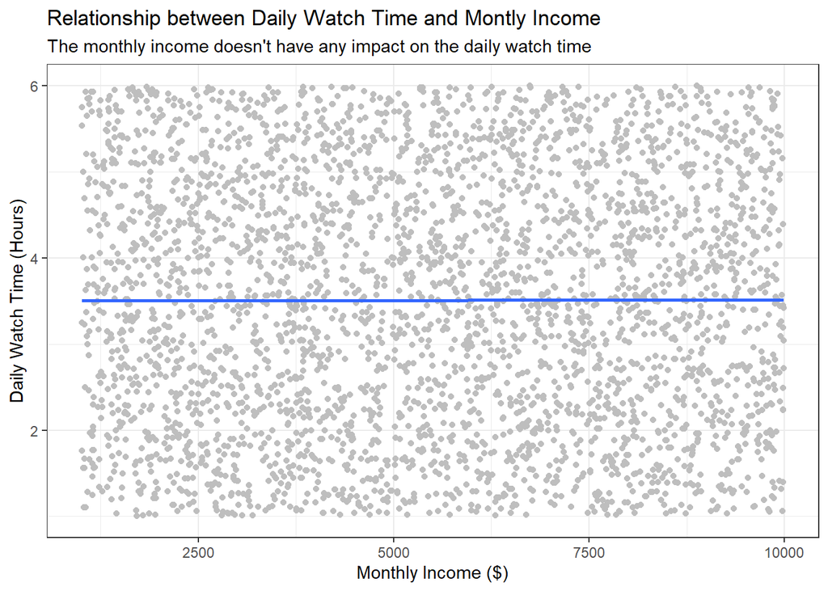

```r
ggplot(data = netflix, aes(x = `Monthly Income ($)`, y = `Daily Watch Time (Hours)`))+
  geom_point(color ='gray' )+
  geom_smooth(method = 'lm', formula = y~x, se = FALSE) +
  labs(
    title = "Relationship between Daily Watch Time and Montly Income ",
    subtitle = "The monthly income doesn't have any impact on the daily watch time"
  )+
  theme_bw()
```

The above chart tells that there is no relationship between the daily watch time and the monthly income since the the trend line ( blue line) is almost horizontal. But let’s run a linear regression test.

### Linear Regression test

```r
netflix.lm <- lm(`Daily Watch Time (Hours)` ~ `Monthly Income ($)`, data = netflix)
summary(netflix.lm) |> pander()
```

|  | Estimate | Std. Error | t value | Pr(>\|t\|) |
| --- | --- | --- | --- | --- |
| **(Intercept)** | 3.504 | 0.0574 | 61.04 | 0 |
| **`Monthly Income ($)`** | 1.014e-06 | 9.463e-06 | 0.1072 | 0.9146 |

Fitting linear model: `Daily Watch Time (Hours)` ~ `Monthly Income ($)`

| Observations | Residual Std. Error | $R^2$ | Adjusted $R^2$ |
| --- | --- | --- | --- |
| 3500 | 1.441 | 3.285e-06 | -0.0002826 |

### Interpretation

With the above test result, we got a p-value of 0.9146 which is pretty high and greater than the level of significance. we do not have sufficient evidence to reject the null hypothesis. This mean there is a possibility to have a null slope. We can then conclude there is not a significant relationship between the monthly Income and the Daily watch time.

### Checking statistic testrequirements

To conduct the linear regression test, we have 5 requirements that need to be met. They are;

1. Linear Relation: the true regression relation between Y and X is linear.
2. Normal Errors: the error terms ϵi are normally distributed with a mean of zero.
3. Constant Variance: the variance σ2 of the error terms is constant (the same) over all Xi values.
4. Fixed X: the Xi values can be considered fixed and measured without error.
5. Independent Errors: the error terms ϵi are independent.

*copy from the textbook*

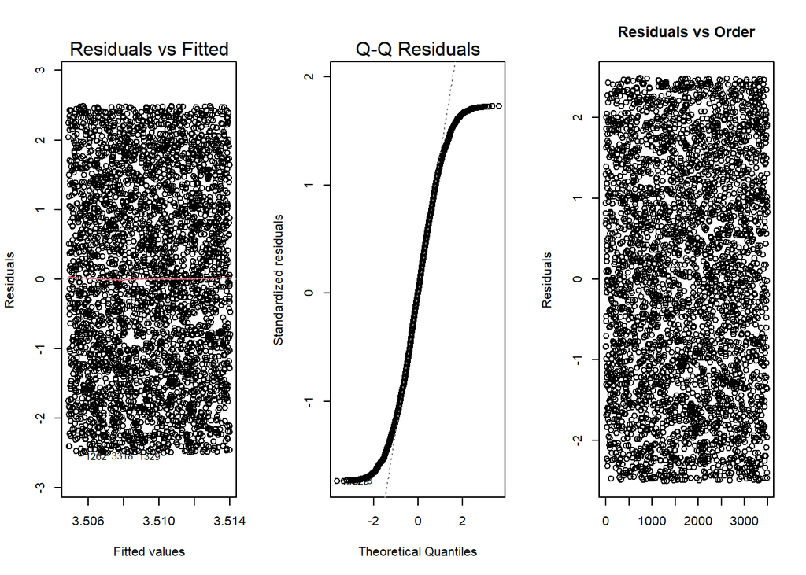

```r
par(mfrow=c(1,3))
plot(netflix.lm, which=1:2)
plot(netflix.lm$residuals, main="Residuals vs Order", xlab="",
     ylab="Residuals")
```

Requirements #1 and #3 are met, as there is no discernible pattern in the Residuals vs. Fitted Values plot.

Requirement #4 is assumed to be met since the monthly incomes are fixed.

Requirement #2 is not met, as indicated by the Q-Q plot.

Requirement #5 is met because there is no visible pattern in the Residuals vs. Order plot.